# 내부수집정보

```r
# packages load
# install.packages("needs")
library(needs)
needs(dplyr,tibble,lubridate,ggplot2,tidyr,readr,gridExtra)
```

```r
# data load
data = read.csv("../data/500pois_collected_manytimes_reEncoded.csv",encoding="iso-8859-1")

data <- data %>% select(-X)

data$date <- substr(data$date_utc,1,10)
data$hr <- substr(data$date_utc,12,13) %>% as.numeric()
data$mn <- substr(data$date_utc,15,16) %>% as.numeric()
data$se <- substr(data$date_utc,18,19) %>% as.numeric()
data <- data %>% select(-date_utc)
data <- data %>% select(date,hr,mn,se,pid,wifi,floor)
data$wifi <- data$wifi %>% paste("\t")
```

### 내부 수집된 매장 번호 개수

```r
# table(data$pid)[table(data$pid) == 1]
# 470702 470968 470981 473412 473473
# 내부 수집이 한번 된 것 제외

data <- data %>% subset(!pid %in% (table(data$pid)[table(data$pid) == 1] %>% dimnames %>% .[[1]] %>% as.numeric))

table(data$pid) %>% length
```

```
## [1] 497
```

```r
# 497개
```

### 매장 선택

```r
nowpid <- data$pid %>% table %>% dimnames %>% .[[1]] %>% .[5]
data1 <- data %>% subset(pid == nowpid)
```

## EDA

```r
new_data_test <- data1$wifi %>%
  strsplit("\t") %>%
  lapply(function(x){matrix(x,ncol=5,byrow=TRUE)[,c(1:4)]})

# wifi new table list
new_data <- data1$wifi %>%
  strsplit("\t") %>%
  lapply(function(x){matrix(x,ncol=5,byrow=TRUE)[,c(1,3,4)] %>% as.tibble(ncol = 3)})
```

```r
# remove wifi information if there is only one
remove_list <- c()
j=1
for(i in 1:length(new_data)){
  if(new_data[[i]] %>% length == 1){
    remove_list[j] <- i
    j=j+1
  }
}

new_data[remove_list] <- NULL
```

```r
# new format of wifi information
for (i in 1:length(new_data)){
  new_data[[i]] <- data1 %>% .$date %>% .[i] %>% ymd %>% rep(nrow(new_data[[i]])) %>%
        cbind(index = i,
              new_data[[i]])

  colnames(new_data[[i]]) <- c("date","index","bssid","rssi","frequency")
}
```

```r
# list to table
total_data <- new_data[[1]]
for(i in 2:length(new_data)){
  total_data <- rbind(total_data,new_data[[i]])
}
total_data$bssid <- as.factor(total_data$bssid)
total_data$rssi <- as.numeric(total_data$rssi)
total_data$frequency <- as.numeric(total_data$frequency)
```

```r
total_data <- total_data %>% group_by(date, index, bssid) %>% summarise(rssi = mean(rssi), frequency = mean(frequency))
```

```r
# date -> factor형 변환
total_data_change <- total_data %>% subset(rssi > -80)
total_data_change$date <- as.factor(total_data_change$date)
```

### wifi bssid plot 1

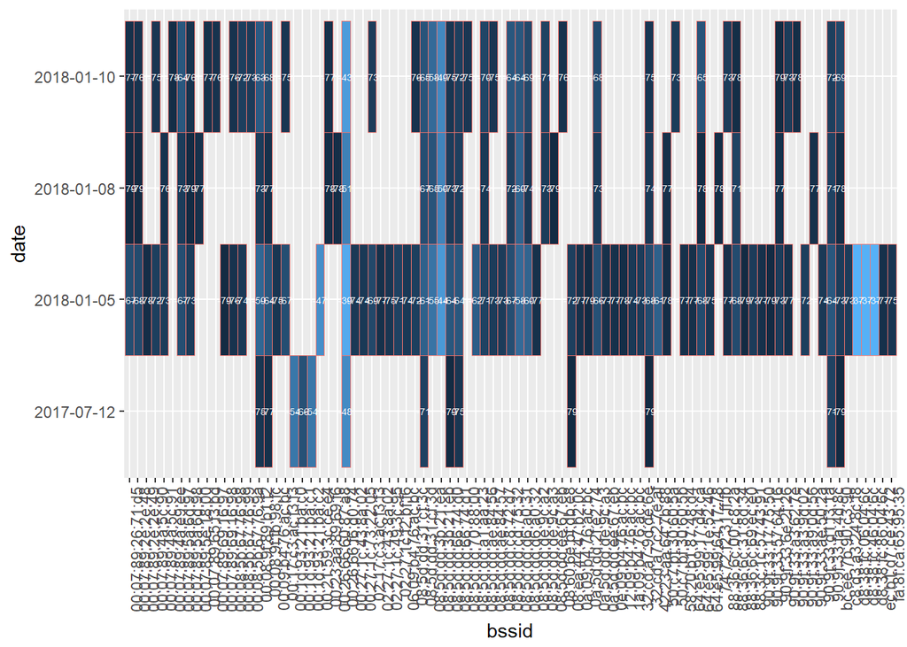

```r
geom.text.size = 1.8

total_data_change %>% ggplot(aes(x=bssid,y=date,color="red")) +
  geom_tile(aes(fill = as.numeric(rssi))) +
  geom_text(aes(x=bssid, y=date,label=as.numeric(rssi)),  size=geom.text.size, color = "white") +
  theme(legend.position = "none" ,
        strip.background = element_blank(),
        strip.text = element_blank(),
        axis.text.x = element_text(angle = 90, hjust = 1))
```

### wifi bssid plot 2

한 매장에서 처음 내부 수집된 와이파이 bssid들이 각 date에서 나온 rssi 결과값을 표시해놓았다.

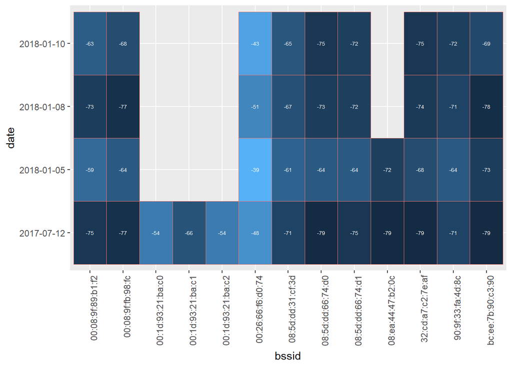

```r
bssid_index2 <- total_data_change %>% .$index %>% unique %>% .[1]
bssid_unique2 <- total_data_change %>% subset(index==bssid_index2) %>% .$bssid

total_data_change2 <-  total_data_change %>% subset(bssid %in% bssid_unique2)

total_data_change2 %>% ggplot(aes(x=bssid,y=date,color="red")) +
  geom_tile(aes(fill = as.numeric(rssi))) +
  geom_text(aes(x=bssid, y=date,label=as.numeric(rssi)),  size=geom.text.size, color = "white") +
  theme(legend.position = "none" ,
        strip.background = element_blank(),
        strip.text = element_blank(),
        axis.text.x = element_text(angle = 90, hjust = 1))
```

### wifi bssid plot 3

한 매장에서 두번째 내부 수집된 와이파이 bssid들이 각 date에서 나온 rssi 결과값을 표시해놓았다.

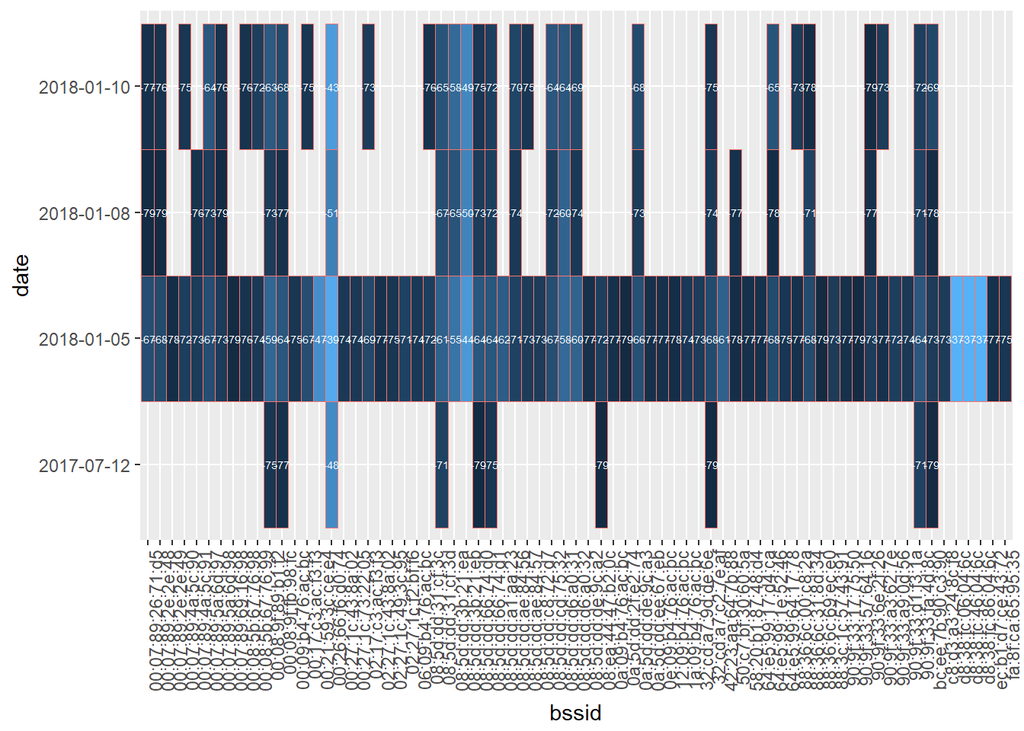

```r
bssid_index3 <- total_data_change %>% .$index %>% unique %>% .[2]
bssid_unique3 <- total_data_change %>% subset(index==bssid_index3) %>% .$bssid

total_data_change3 <-  total_data_change %>% subset(bssid %in% bssid_unique3)

total_data_change3 %>% ggplot(aes(x=bssid,y=date,color="red")) +
  geom_tile(aes(fill = as.numeric(rssi))) +
  geom_text(aes(x=bssid, y=date,label=as.numeric(rssi)),size=geom.text.size, color = "white") +
  theme(legend.position = "none" ,
        strip.background = element_blank(),
        strip.text = element_blank(),
        axis.text.x = element_text(angle = 90, hjust = 1))
```

### wifi bssid plot 4

한 매장에서 세번째 내부 수집된 와이파이 bssid들이 각 date에서 나온 rssi 결과값을 표시해놓았다.

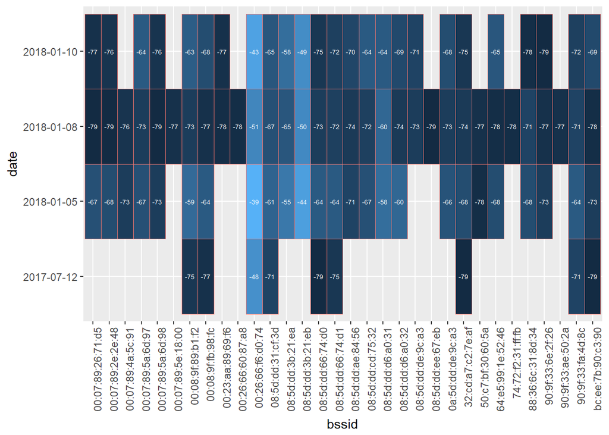

```r
bssid_index4 <- total_data_change %>% .$index %>% unique %>% .[3]
bssid_unique4 <- total_data_change %>% subset(index==bssid_index4) %>% .$bssid
total_data_change4 <-  total_data_change %>% subset(bssid %in% bssid_unique4)

total_data_change4 %>% ggplot(aes(x=bssid,y=date,color="red")) +
  geom_tile(aes(fill = as.numeric(rssi))) +
  geom_text(aes(x=bssid, y=date,label=as.numeric(rssi)),  size=geom.text.size, color = "white") +
  theme(legend.position = "none" ,
        strip.background = element_blank(),
        strip.text = element_blank(),
        axis.text.x = element_text(angle = 90, hjust = 1))
```

### wifi bssid plot 5

한 매장에서 네번째 내부 수집된 와이파이 bssid들이 각 date에서 나온 rssi 결과값을 표시해놓았다.

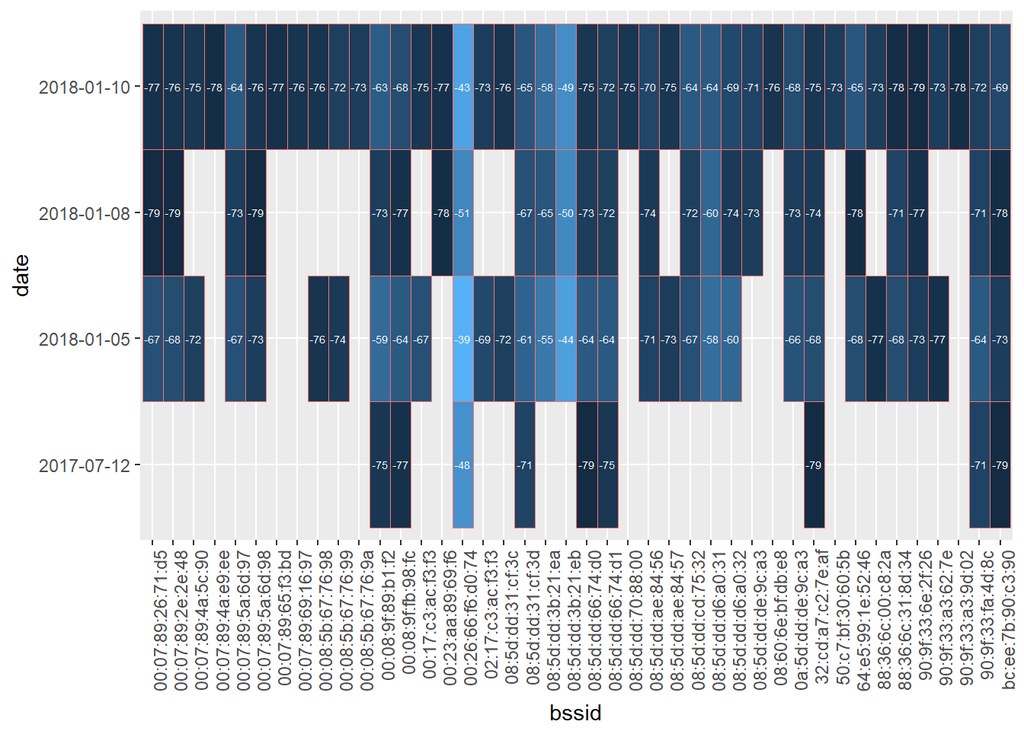

```r
bssid_index4 <- total_data_change %>% .$index %>% unique %>% last
bssid_unique4 <- total_data_change %>% subset(index==bssid_index4) %>% .$bssid
total_data_change4 <-  total_data_change %>% subset(bssid %in% bssid_unique4)

total_data_change4 %>% ggplot(aes(x=bssid,y=date,color="red")) +
  geom_tile(aes(fill = as.numeric(rssi))) +
  geom_text(aes(x=bssid, y=date,label=as.numeric(rssi)),  size=geom.text.size, color = "white") +
  theme(legend.position = "none" ,
        strip.background = element_blank(),
        strip.text = element_blank(),
        axis.text.x = element_text(angle = 90, hjust = 1))
```

```r
# 주파수 빼고 생각해보자. 별 의미 없는 거 같아요!!(test_freq_bridge_rssi.R)

# 어느 정도 되면 와이파이 신호가 안잡힐까? -> 실험적으로 알아봐야하나>
# 매장으로 인식 안될정도는 언제인가? 어느정도 와이파이 변화가 일어나야 매장으로 인식을 못할까?를 알아야 한다.
# 이걸 정하면 이제 실험해보면 된다!! -80기준이든 뭐든 그건 좀이따의 상황인듯?

# 와이파이를 버릴건 버리자 예를들어, -80을 기준으로 삭제를 한다거나??
# 이건 실제에서 확인해봐야할거같아

## 여기서 나는 무엇을 하고 싶은가?
#### 내부 수집에서 나타난 와이파이 10개 중에 6개만 검출되면 1/2 * 6/10,
#### 전체 와이파이 10개에서 새로운 와이파이 4개가 잡히면
#### 1/2 * (1-4/10) 식으로 가중치를 줘서 값을 구할 수 있지 않을까?
```